# Assembly report

Bfr Bioinformatics

08 May, 2019

# Assembly report for run AQUAMIS

## Overview

- Run name: SCRATCH_NOBAK
- Number of assembled samples: 8
- Number of fails: 0
- Run directory: /home/tauschs/SCRATCH_NOBAK/AQUAMIS/finaltest
- Location of trimmed fastq files: /home/tauschs/SCRATCH_NOBAK/AQUAMIS/finaltest/trimmed
- Location of fasta files: /home/tauschs/SCRATCH_NOBAK/AQUAMIS/finaltest/Assembly/assembly

### Failed runs

0 samples failed.

Likely reasons are that too few reads were provided, coverage was too low or pilon read mapping failed. For more details, have a look at the log files in /home/tauschs/SCRATCH_NOBAK/AQUAMIS/finaltest/logs.

## Short summary table

| sample name | species | total length | Q30 base fraction | coverage depth | single-copy orthologs | duplicated orthologs |
| --- | --- | --- | --- | --- | --- | --- |
| GMI-17-001-DNA | Salmonella enterica | 4667259 | 0.885926 | 77.8469 | 0.986 | 0 |
| GMI-17-002-DNA | Salmonella enterica | 5091799 | 0.901715 | 70.743 | 0.986 | 0 |
| GMI-17-003-DNA | Escherichia coli | 5363647 | 0.889518 | 46.2587 | 0.98 | 0 |
| GMI-17-004-DNA | Escherichia coli | 4867200 | 0.905818 | 73.9097 | 0.986 | 0 |
| GMI-17-005-DNA | Staphylococcus aureus | 2763419 | 0.947136 | 77.8517 | 0.986 | 0 |
| GMI-17-006-DNA | Staphylococcus aureus | 2883012 | 0.945464 | 101.087 | 0.986 | 0 |
| GMI15-001-DNA | Salmonella enterica | 4878954 | 0.846369 | 75.101 | 0.986 | 0 |
| GMI15-002-DNA | Salmonella enterica | 5171508 | 0.842406 | 81.0555 | 0.986 | 0 |

## Detailed assembly table

The table is searchable and sortable. At the end, clickable links are provided to the created fasta file, to the best ncbi reference contig and to the quast and icarus reports.

Note that the best reference is selected from the set of all complete bacterial chromosome assemblies. Hence plasmids are excluded which in turn might reflect in a larger genome length of the sample than the reference. Futhermore, for bacteria with more than one chromosome, only the best matching chromosome is reported. Thus gene count, reference length etc. are properties of the best matching chromosome.

| sample name | reference | # reads | Megabases | Q30 base fraction | coverage depth | # contigs | single-copy orthologs | duplicated orthologs | N50 | # genes | # partial genes | fraction genes recovered | reference coverage | total length | reference length | reference similarity | #circular contigs | fraction mapped reads | insert size | details trimming | fasta | ncbi | ikarus | quast |
| --- | --- | --- | --- | --- | --- | --- | --- | --- | --- | --- | --- | --- | --- | --- | --- | --- | --- | --- | --- | --- | --- | --- | --- | --- |
| GMI-17-001-DNA | Salmonella enterica strain CFSAN064033 | 1558416 | 366.635021 | 0.885926 | 77.8469 | 80 | 0.986 | 0 | 127089 | 4777 | 44 | 0.969824984912492 | 0.98535 | 4667259 | 4636770 | 0.958 | 4 | 0.998002458906993 | 642.813451778589 | fastp | file | NZ_CP028172.1 | ikarus | quast |
| GMI-17-002-DNA | Salmonella enterica strain CFSAN064034 | 1567344 | 364.345526 | 0.901715 | 70.743 | 135 | 0.986 | 0 | 91324 | 5090 | 69 | 0.966466841513676 | 0.98031 | 5091799 | 4941290 | 0.949 | 4 | 0.998941521452853 | 570.835244892701 | fastp | file | NZ_CP028169.1 | ikarus | quast |
| GMI-17-003-DNA | Escherichia coli strain AR_0019 | 1061486 | 251.863182 | 0.889518 | 46.2587 | 195 | 0.98 | 0 | 112495 | 4655 | 87 | 0.949349349349349 | 0.96144 | 5363647 | 4643903 | 0.785 | 3 | 0.997999973621885 | 640.505861074123 | fastp | file | NZ_CP024889.1 | ikarus | quast |
| GMI-17-004-DNA | Escherichia coli strain CFSAN064036 | 1533220 | 364.927543 | 0.905818 | 73.9097 | 150 | 0.986 | 0 | 93015 | 4969 | 77 | 0.957313602731929 | 0.97121 | 4867200 | 4815114 | 0.945 | 3 | 0.997032389350517 | 592.998814581871 | fastp | file | NZ_CP028166.1 | ikarus | quast |
| GMI-17-005-DNA | Staphylococcus aureus strain CFSAN064037 | 934594 | 217.367483 | 0.947136 | 77.8517 | 81 | 0.986 | 0 | 74371 | 2857 | 38 | 0.964678440519827 | 0.97569 | 2763419 | 2790673 | 0.971 | 1 | 0.997868593207318 | 568.662797328335 | fastp | file | NZ_CP028165.1 | ikarus | quast |
| GMI-17-006-DNA | Staphylococcus aureus strain CFSAN064038 | 1222552 | 294.441291 | 0.945464 | 101.087 | 64 | 0.986 | 0 | 106576 | 3049 | 31 | 0.972836386607707 | 0.983 | 2883012 | 2882275 | 0.982 | 2 | 0.999415975762176 | 550.433970869777 | fastp | file | NZ_CP028163.1 | ikarus | quast |
| GMI15-001-DNA | Salmonella enterica subsp. enterica serovar Typhimurium strain CFSAN018746 | 1334908 | 369.607374 | 0.846369 | 75.101 | 87 | 0.986 | 0 | 178567 | 5013 | 60 | 0.969610091743119 | 0.98513 | 4878954 | 4857558 | 0.975 | 0 | 0.99951682063483 | 470.049925913559 | fastp | file | NZ_CP028199.1 | ikarus | quast |
| GMI15-002-DNA | Salmonella enterica subsp. enterica serovar Concord strain CFSAN018747 | 1502576 | 422.796875 | 0.842406 | 81.0555 | 86 | 0.986 | 0 | 192104 | 4949 | 42 | 0.976712328767123 | 0.98866 | 5171508 | 4740838 | 0.89 | 0 | 0.999469577578771 | 490.6316172432 | fastp | file | NZ_CP028196.1 | ikarus | quast |

## Detailed trimming table

| sample | total reads before | total bases before | total reads after | total bases after | q20 rate after | q30 rate after | duplication rate | insert size peak | link to report |
| --- | --- | --- | --- | --- | --- | --- | --- | --- | --- |
| GMI15-001-DNA | 1357838 | 375628729 | 1334908 | 368272466 | 0.921169 | 0.846369 | 0.00289187 | 300 | fastp |
| GMI15-002-DNA | 1533142 | 430972134 | 1502576 | 421294299 | 0.918517 | 0.842406 | 0.00324734 | 340 | fastp |
| GMI-17-001-DNA | 1588118 | 372135045 | 1558416 | 365076605 | 0.951266 | 0.885926 | 0.00286174 | 35 | fastp |
| GMI-17-002-DNA | 1589558 | 367924871 | 1567344 | 362778182 | 0.958792 | 0.901715 | 0.0034537 | 424 | fastp |
| GMI-17-003-DNA | 1085870 | 256692676 | 1061486 | 250801696 | 0.951879 | 0.889518 | 0.00315405 | 35 | fastp |
| GMI-17-004-DNA | 1554330 | 368364675 | 1533220 | 363394323 | 0.96105 | 0.905818 | 0.00328424 | 465 | fastp |
| GMI-17-005-DNA | 939304 | 217422160 | 934594 | 216432889 | 0.982457 | 0.947136 | 0.00408766 | 455 | fastp |
| GMI-17-006-DNA | 1228160 | 294530058 | 1222552 | 293218739 | 0.982192 | 0.945464 | 0.00529129 | 452 | fastp |

## Plots per run

### Coverage depth

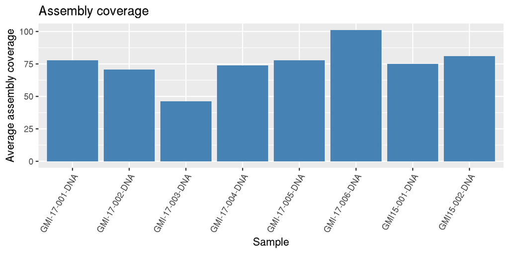

Figure 1: Average assembly coverage depth of all mapped reads (per sample).

### Fraction of recovered reference genes

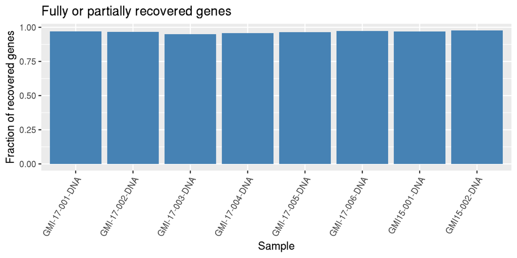

Figure 2: Fraction of reference genes fully or partially found in assembly. Note that if a genome consists of more than one chromosome, only the fraction beloning to the largest chromosome is displayed.

### Fraction of reads mapped to contigs

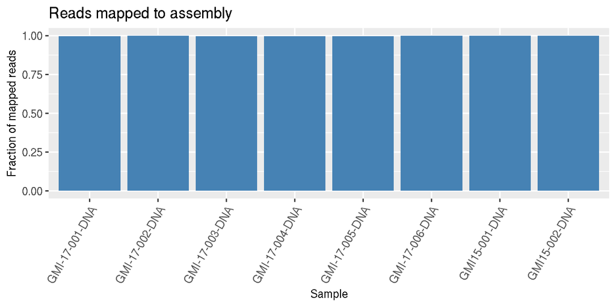

Figure 3: Fraction of reads that map back to the assembly. A lower fraction indicates problems with the assembly and/or contamination in a sample.

### Insert size distribution

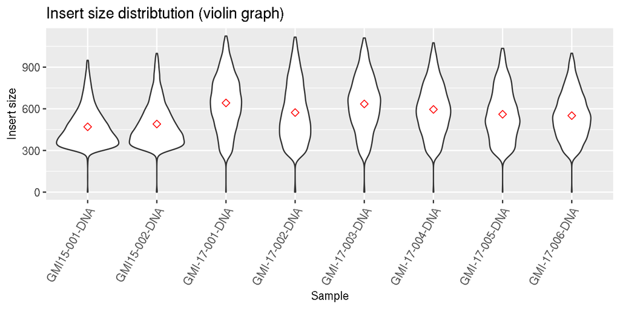

Figure 4: Insert size distrubution per sample (violin plot). The mean insert sizes are indicated by red diamonds. The insert size is the same as the fragment size without barcodes. Thus, if the insert size is smaller than two times the read length, the reads overlap.

### Circular contigs analysis

- contigs are checked to be circular and re-oriented
- Unicycler yields the following information: contig name, length, relative depth, absolute depth
- Information is stored in assembly.fasta

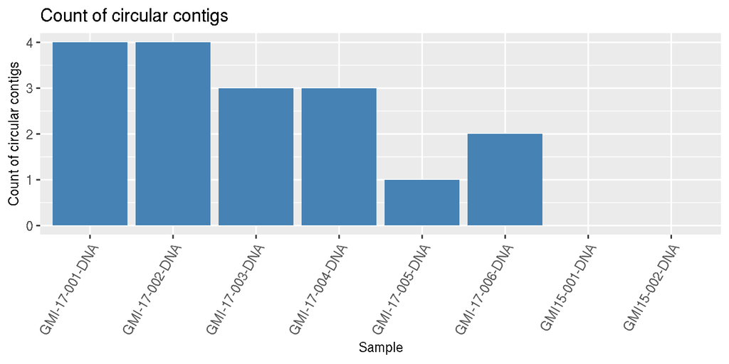

Figure 5: Number of circular contigs per sample.

### Coverage depth distribution

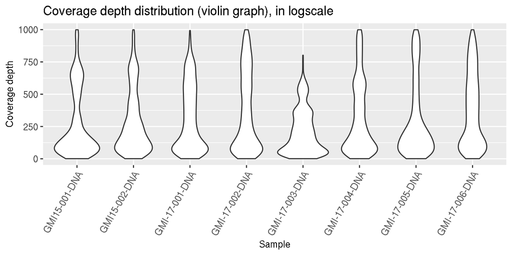

Figure 6: Coverage depth distribution of each sample(violin graph), in logscale. Each separate bubble indicates the presence of a DNA molecule with a defined coverage depth distribition. Hence, the presence of more than one bubble may be associated with the presence of (high copy number) plasmids.

## Plots per sample

### Coverage depth distribution

In the following, the coverage depth distribution is shown for each sample (in logscale):

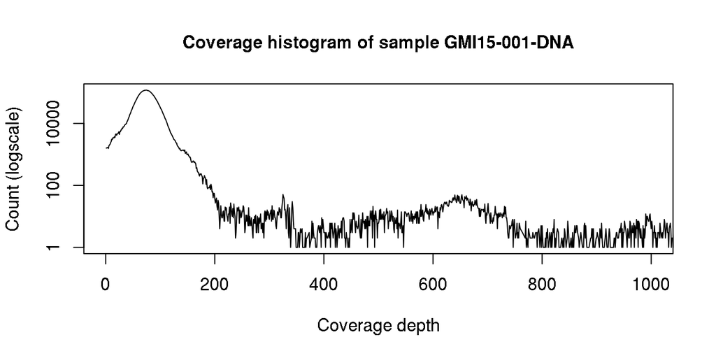

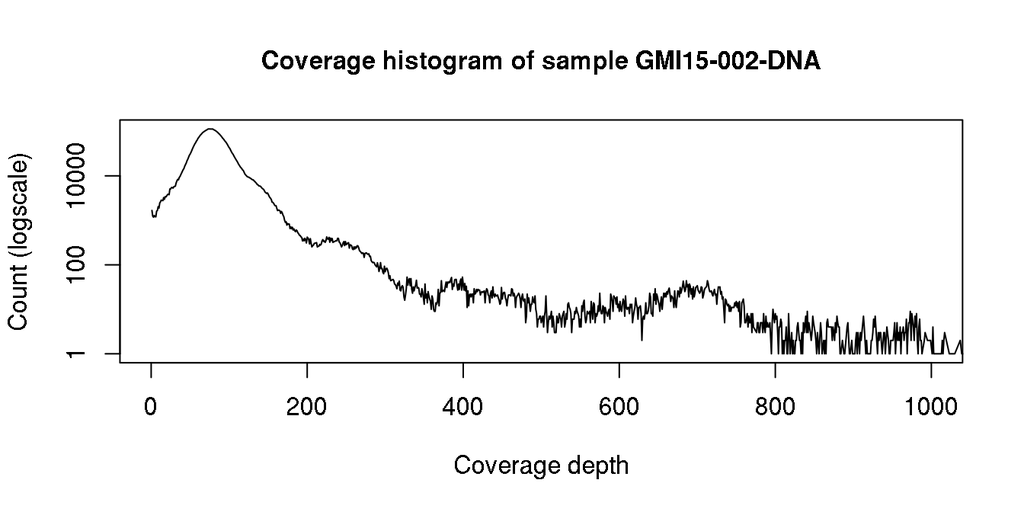

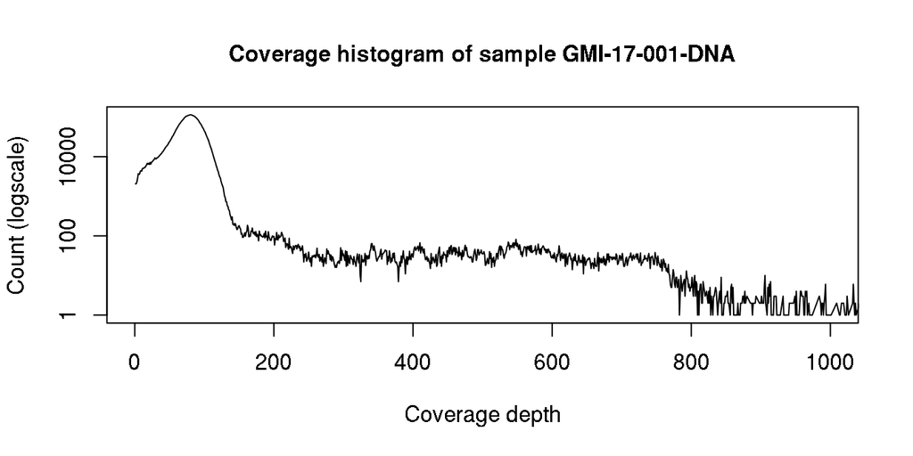

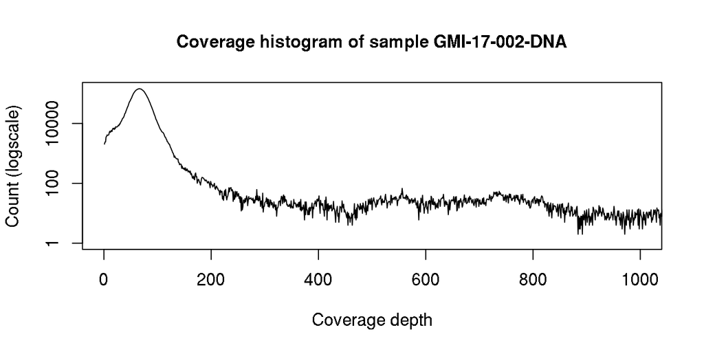

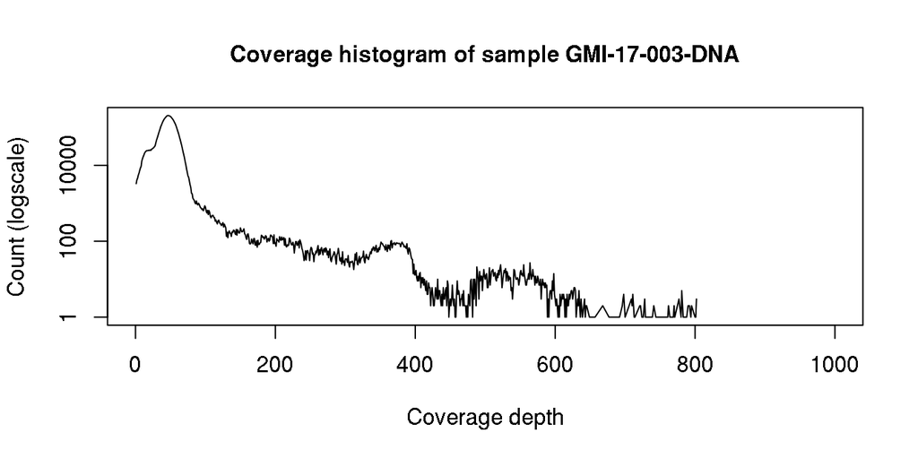

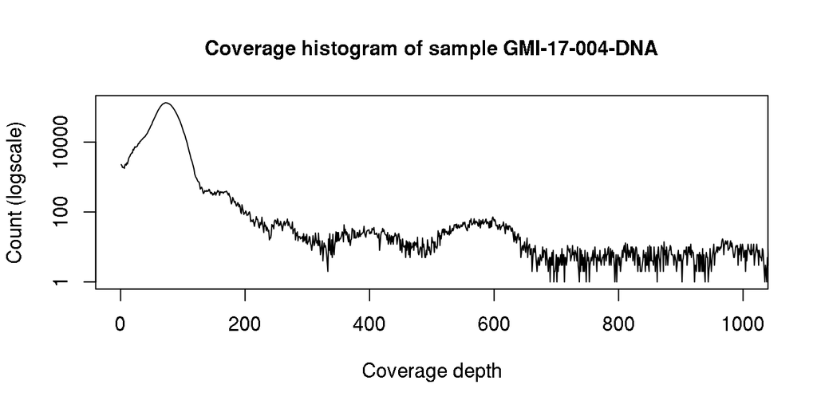

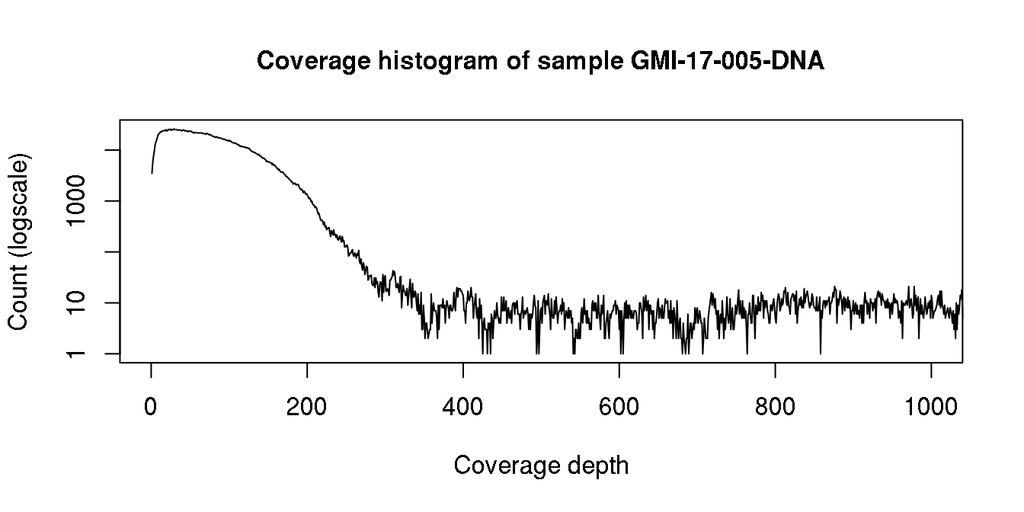

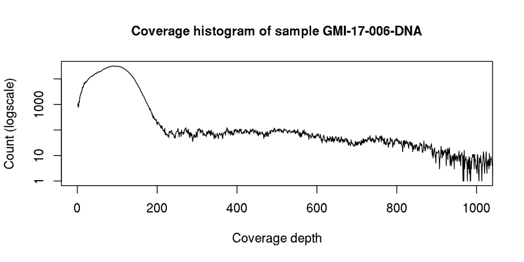

## Program versions/ log

- config file: /home/tauschs/SCRATCH_NOBAK/AQUAMIS/finaltest/config.yaml.
- logfiles in folder /home/tauschs/SCRATCH_NOBAK/AQUAMIS/finaltest/logs.
- program versions are available in the conda env files
- snakemake logs: * config file: /home/tauschs/SCRATCH_NOBAK/AQUAMIS/finaltest/.snakemake.
- main programs are unicycler, spades, pilon, blast and quast

## Help

| Column | Details |
| --- | --- |
| sample name | Name of sample |
| reference | Best NCBI complete genome according to mash |
| # reads | Number of reads after trimming |
| Megabases | Number of bases from all trimmed reads |
| Q30 base fraction | Fraction of bases that have Q30 or higher |
| coverage depth | Average depth over all positions and contigs |
| # contigs | Number of contigs |
| single-copy orthologs | Fraction of universal single-copy orthologs that were found. Values below 1 indicate incompleteness |
| duplicated orthologs | Fraction of universal single-copy orthologs that were found in duplicate. Non-zero indicate contamination |
| N50 | N50 value in basepairs (indicator of average contig size and assembly quality) |
| # genes | Number of reference genes found |
| # partial genes | Number of reference genes partially found |
| fraction genes recovered | Fraction of genes found compared to all reference genes, includes partial matches |
| reference coverage | Genome coverage compared to reference |
| total length | Sum of all contigs |
| reference length | Length of reference genomes |
| reference similarity | Similarity to reference according to mash. The value describes the fraction of shared kmers. |
| #circular contigs | Number of contigs that could be circularized (flagged with ‘circular=true’ in fasta header) |
| fraction mapped reads | Fraction of reads that map to contigs. Values below 1 indicate assembly issues |
| insert size | Calculated fragment length , i.e. read length plus insert size |
| details trimming | fastp report with details related to read trimming and read QC |
| fasta | Link to assembly file |
| ncbi | Link to reference NCBI entry |
| ikarus | Link to ikarus report on structural comparison to reference |
| quast | Link to assembly quality report |